# Midterm Project Written Presentation

County-level Oil and Gas Production

Mengze Yin

October 24, 2016

### 1. Introduction

In this assignment, the dataset “County-level oil and gas production” (Reference: www.ers.usda.gov) is chosen as the raw dataset, which records each county’s FIPS code, county level, including population level, urban influence, size of county, etc., annual oil and gas production from 2000 to 2011, and the categorical group based upon change in the dollar value of the oil and gas production of the county to explore the relationship between population level and oil and gas production. For this project using R, the objectives are: first, cleaning the dataset and giving a tidy dataset with annual production of oil and gas for each county; second, summarizing the dataset and provide some basic statistics that may be used for future exploration on this dataset; finally, visualizing some relationship between county, county level, the production amount and year. The completion of this project is under collaboration of three members: Yilin Li, Mengze Yin and Tianchi Zhang, who had equally contributed to the coding in R.

### 2. Tidy Data

In this part, I aim to reorganize the raw dataset and turn it into a tidy dataset for further analysis. First, read the csv. Table into R and revise columns’ names for readily. Then, when viewing the dataset, I find it consists of two parts: one with the information of the county level, the other one with the production amount for each year. So, I spilt the dataset into two tables. First, I select the information of County from the raw dataset to form a table with county information using function “select”, and get a table called “county”. Second, I select information on annual production for each county from the raw dataset and get a table called “oil_gas0”. Since there are multiple variables stored in columns such as “oil2000” which contains the type of production and year, I firstly gather up the non-variable columns and secondly separate column headers to get a tidy dataset called “oil_gas_tidy”.

### 3. Dataset Summary

In this part, I aim to provide some basic statistic summary of this dataset for further analysis. First of all, based on carefully reading on the raw dataset, I found Population level and other categorical county levels is closly related, therefore, in this project, I will only use population level as the mearsurement of county level. The first summary I do is the average annual oil and gas production for each county, which may help to compare the production difference between each county. The second one I do is the national wide mean production (per county) in each year which aim to trace the change of nationwide oil and gas production for each year. Thirdly, I give a tidy table with average oil and gas production for counties by each population level, which may help to explore the relationship between county level and the oil and gas production.

### 4. Visualization

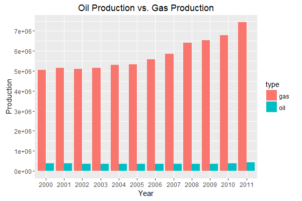

The Second is a pair of graphs showing the mean production level of oil and gas in different county level.

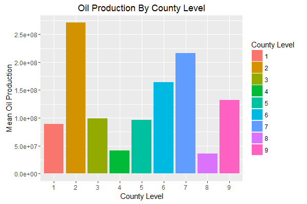

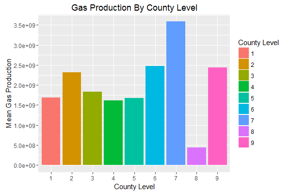

The third is a pair of scatterplots showing how those couties lie in diffenrent county levels and oil&gas production amount.

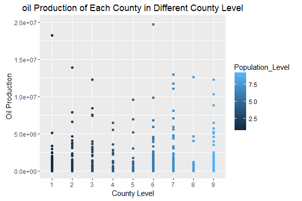

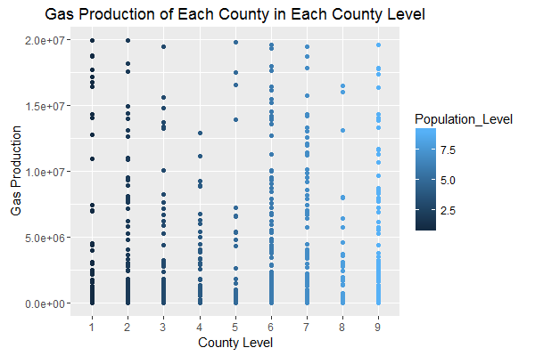

The fourth is pair of graphs showing the change in oil and gas production for each county level from 2000 to 2011.

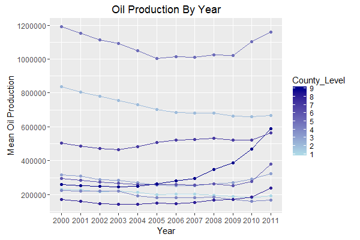

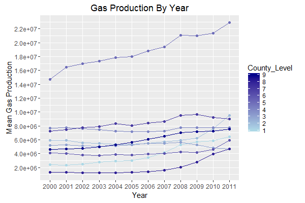

The fifth is a pair of stack columns shows the total production each year for all 9 county levels from 2000 to 2011, it is a comparison to the fourth, which additionaly shows the total production.

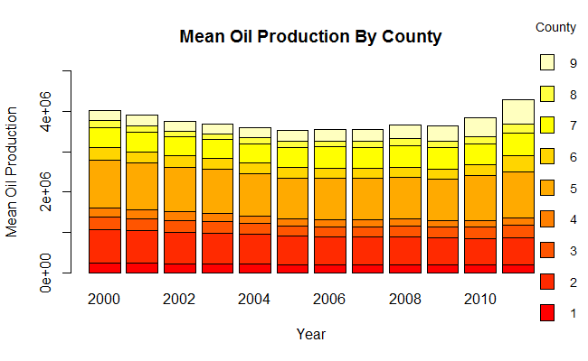

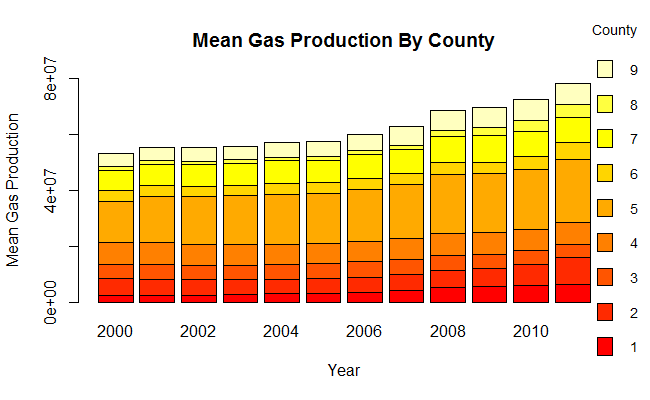

The sixth is a pair of demographic maps of oil and gas production for each county through 2001 to 2011.

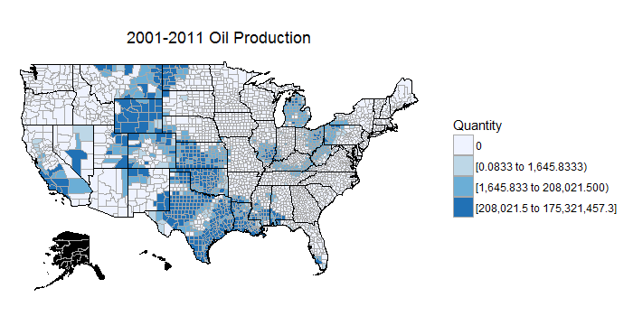

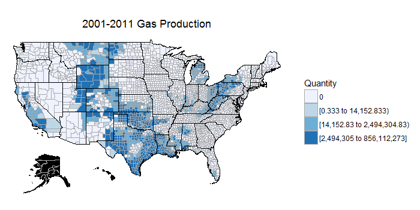